[OHI-Northeast](http://www.ohi-northeast.org/) | [OHI Science](http://ohi-science.org) | [Citation policy](http://ohi-science.org/citation-policy/)

# OHI-Northeast: Pathogens

Compiled on Fri Nov 15 15:24:40 2019 by afflerbach

## Summary

This layer is derived from [EPA Beach Closure](https://watersgeo.epa.gov/beacon2/) data. We use the number of days a beach is closed per year due to pathogens in the water as a proxy for the impact of pathogens in coastal waters. Data is provided at the beach level and aggregated to the region level. Our reference point is 100 days free of closures, representing the average length of the swimming season for the region.

**NOTE** Ideally we would also use the EPA BEACON Beach Days dataset which lists the number of beach days in each swimming season, as well as the number of days closed/opened. We could use the total number of beach days in each swimming season to better calibrate the reference point. But it is clear that the data for Beach Days in the BEACON dataset is not consistent year to year or beach to beach. Many of the beaches list 0 total beach days, which we feel is incorrect. But we can get a general estimate for number of beach days using the beach days dataset.

```r
knitr::opts_chunk$set(fig.width = 10, fig.height = 6, fig.path = 'figs/', message = FALSE, warning = FALSE)

source('~/github/ne-prep/src/R/common.R')

library(tidyverse)
```

## Data Wrangling

### Beach Closure data

The beach action (advisory and closures) data was downloaded for New York separately from the rest of the region since NY is not included in the New England EPA region.

### New York beaches data

I downloaded the New York beaches dataset on its own.

```r
ny_beach_closures <- read_csv(file.path(dir_anx, ('_raw_data/EPA/beach_actions_(advisories_and_closures)_NY.csv'))) %>%
      filter(County %in% c('BRONX','QUEENS','KINGS','SUFFOLK','NASSAU','RICHMOND','WESTCHESTER')) %>% #ocean counties
      mutate(state = "New York",
             rgn_id = 10) %>% #add OHI region id which is 10 for new york
   select(state, County, Year, `Beach Name`, ActionStartDate, ActionEndDate, `ActionDuration Days`, rgn_id, `Action Reasons`)
```

## Beach days dataset

This dataset sseems to have some errors where many beaches have 0 days listed under both “No. of days with Beach Action” and “No. of days not under beach action”. A lot of beaches are also repeated in the year 2011 for unknown reasons.

```r
#this dataset tells us the total number of beach days for each beach/year
ny_beach_days <- read_csv(file.path(dir_anx, ("_raw_data/EPA/beach_days_ny.csv"))) %>%
  filter(County %in% c('BRONX','QUEENS','KINGS','SUFFOLK','NASSAU','RICHMOND','WESTCHESTER')) #ocean counties

ny_beach_days %>% filter(`Beach Name` == "BEEKMAN BEACH")
```

```
## # A tibble: 125 x 11
##    State  Year `Beach ID` `Beach Name` County `Beach Status` Monitored
##    <chr> <dbl> <chr>      <chr>        <chr>  <chr>          <chr>
##  1 NY     2014 NY401633   BEEKMAN BEA… NASSAU Reporting      -
##  2 NY     2013 NY401633   BEEKMAN BEA… NASSAU Reporting      -
##  3 NY     2012 NY401633   BEEKMAN BEA… NASSAU Reporting      -
##  4 NY     2011 NY401633   BEEKMAN BEA… NASSAU Reporting      -
##  5 NY     2011 NY401633   BEEKMAN BEA… NASSAU Reporting      -
##  6 NY     2011 NY401633   BEEKMAN BEA… NASSAU Reporting      -
##  7 NY     2011 NY401633   BEEKMAN BEA… NASSAU Reporting      -
##  8 NY     2011 NY401633   BEEKMAN BEA… NASSAU Reporting      -
##  9 NY     2011 NY401633   BEEKMAN BEA… NASSAU Reporting      -
## 10 NY     2011 NY401633   BEEKMAN BEA… NASSAU Reporting      -
## # … with 115 more rows, and 4 more variables: `No. of DaysUnderBeach
## #   Action` <dbl>, `Percent DaysUndera BeachAction` <dbl>, `No. of DaysNot
## #   UnderBeach Action` <dbl>, `Percent DaysNot Undera BeachAction` <dbl>
```

To get an average number of days for NY beach season, I filter to keep only those beaches where the percent of days under a closure and not under a closure adds up to 100 (the assumption is that this data is filled out).

```r
ny_beach_clean <- ny_beach_days %>%
  rowwise() %>%
  mutate(beach_days = sum(`No. of DaysUnderBeach Action`, `No. of DaysNot UnderBeach Action`),
         perc = sum(`Percent DaysNot Undera BeachAction`, `Percent DaysUndera BeachAction`)) %>%
  filter(perc == 100) %>%
  group_by(Year, `Beach Name`, County) %>%
  summarize(avg_beach_days = mean(beach_days, na.rm = T))

avg_ny_beach_days <- mean(ny_beach_clean$avg_beach_days)
avg_ny_beach_days
```

```
## [1] 104
```

### All other states

Here we load the New England dataset.

```r
# data for all states exept New York
df <- read_csv(file.path(dir_anx, ('_raw_data/EPA/beach_actions_(advisories_and_closures).csv'))) %>%
        mutate(state =
                   case_when(
                     State == "MA" ~ "Massachusetts",
                     State == "CT" ~ "Connecticut",
                     State == "ME" ~ "Maine",
                     State == "NH" ~ "New Hampshire",
                     State == "RI" ~ "Rhode Island"
                   ))
```

### Beach Days

Again we want average number of beach days by state. We will do a similar method to NY.

```r
#this dataset tells us the total number of beach days for each beach/year
ne_beach_days <- read_csv(file.path(dir_anx, ("_raw_data/EPA/beach_days.csv"))) %>%
  rowwise() %>%
  mutate(beach_days = sum(`No. of DaysUnderBeach Action`, `No. of DaysNot UnderBeach Action`),
         perc = sum(`Percent DaysNot Undera BeachAction`, `Percent DaysUndera BeachAction`)) %>%
  filter(perc == 100) %>%
  group_by(State) %>%
  summarize(avg_beach_days = mean(beach_days))

ne_beach_days
```

```
## # A tibble: 5 x 2
##   State avg_beach_days
##   <chr>          <dbl>
## 1 CT              98.0
## 2 MA             101.
## 3 ME              99.3
## 4 NH              97.3
## 5 RI              97.7
```

### Split Massachusetts between two regions

Since Massachussetts has state waters divided into two regions, we have to manually assign counties to the Northern and Southern regions

```r
split <- df %>%
          filter(County %in% c('BARNSTABLE','PLYMOUTH')) %>%
          select(State, County, `Beach Name`) %>%
          unique()

nrow(split)
```

```
## [1] 198
```

```r
write_csv(split, 'data/ma_beaches.csv')
```

There are 198 beaches in these two counties that require manual matching. Using the [BEACON map viewer](https://watersgeo.epa.gov/beacon2/Beacon.html), I matched each beach in Plymouth and Barnstable Counties to either Region 7 or 8.

Now combine all beaches to rgn_ids

```r
#read in the BARNSTABLE/PLYMOUTH beach dataset that identifies what region each beach belongs to
mass_bch <- read_csv('data/ma_beaches_rgn_id.csv')[, 1:4] %>%
  mutate(state = "Massachusetts") %>%
  select(-State)

#get MA counties
mass_cnty <- read_csv('~/github/ne-prep/src/tables/MA_counties.csv')[, 2:4]
mass_cnty$County = toupper(mass_cnty$County)

#get just barnstable and plymouth county data from MA and left join with mass_bch to identify rgn 7 or 8
df_pb <- df %>%
         filter(state == 'Massachusetts' & County %in% c('BARNSTABLE', 'PLYMOUTH')) %>%
         left_join(mass_bch, by = c('state', 'County', 'Beach Name')) %>%
         select(state, County, Year, `Beach Name`, ActionStartDate, ActionEndDate, `ActionDuration Days`, rgn_id, `Action Reasons`)

#get the rest of the MA data without those two counties and join with the mass_cnty to identify rgn 7 or 8
df_ma <- df %>%
        filter(state == 'Massachusetts'&
               !County %in% c('BARNSTABLE', 'PLYMOUTH')) %>%
        left_join(mass_cnty, by = 'County') %>%
        select(state, County, Year, `Beach Name`, ActionStartDate, ActionEndDate, `ActionDuration Days`, rgn_id, `Action Reasons`)
```

### Combine all

Combine the two MA datasets along with NY

```r
#matching rgn_id to non MASS data
df_rest <- df %>%
            filter(state != 'Massachusetts') %>%
            left_join(rgn_data, by = "state") %>%
            select(state, County, Year, `Beach Name`, ActionStartDate, ActionEndDate, `ActionDuration Days`, rgn_id, `Action Reasons`)

df_all = rbind(df_pb, df_ma, df_rest, ny_beach_closures) %>%
          left_join(rgn_data, by = c('rgn_id', 'state'))
```

## Look at reasons for beach closure

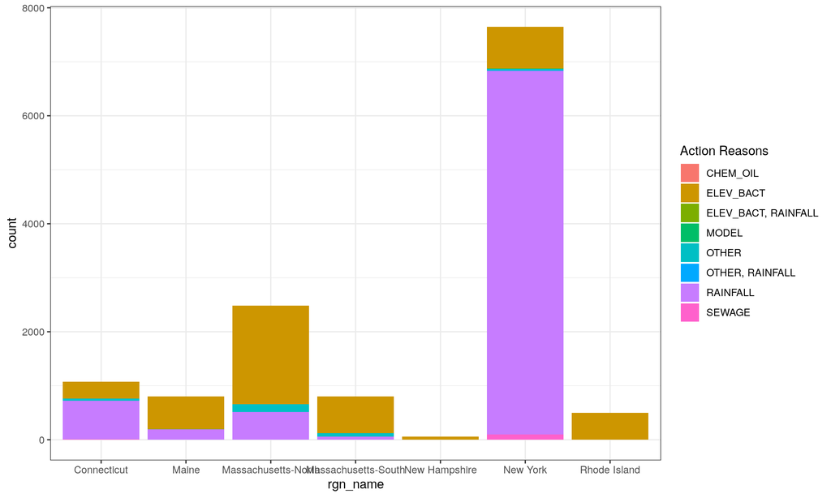

```r
ggplot(df_all, aes(x = rgn_name)) +
  geom_bar(aes(fill = `Action Reasons`)) +
  theme_bw()
```

We want to filter out “OTHER” but keep the rest since they indicate beaches are closed due to water quality issues such as elevated bacteria or sewage, or runoff from rainfall.

## Calculate percent closed by region

Percent of days each beach is closed then take the mean for each region

```r
perc_states <- df_all %>%
        filter(`Action Reasons` != "OTHER") %>%
        unique() %>% #some weird duplicates
        group_by(`Beach Name`, Year, County, rgn_id, rgn_name) %>%
        summarize(days_closed = sum(`ActionDuration Days`)) %>%
        mutate(perc_closed = days_closed/100) %>%
        ungroup() %>%
        group_by(rgn_name, rgn_id, Year) %>%
        summarize(perc_closed = mean(perc_closed))
```

Do this again but across the entire region

```r
perc_ne <- df_all %>%
        filter(`Action Reasons` != "OTHER") %>%
        unique() %>% #some weird duplicates
        group_by(`Beach Name`, Year, County, rgn_id, rgn_name) %>%
        summarize(days_closed = sum(`ActionDuration Days`)) %>%
        mutate(perc_closed = days_closed/100) %>%
        ungroup() %>%
        group_by(Year) %>%
        summarize(perc_closed = mean(perc_closed)) %>%
        mutate(rgn_id = 12,
        rgn_name = "Northeast")
```

Combine all regions

```r
perc <- bind_rows(perc_states, perc_ne)
```

## Visualize data

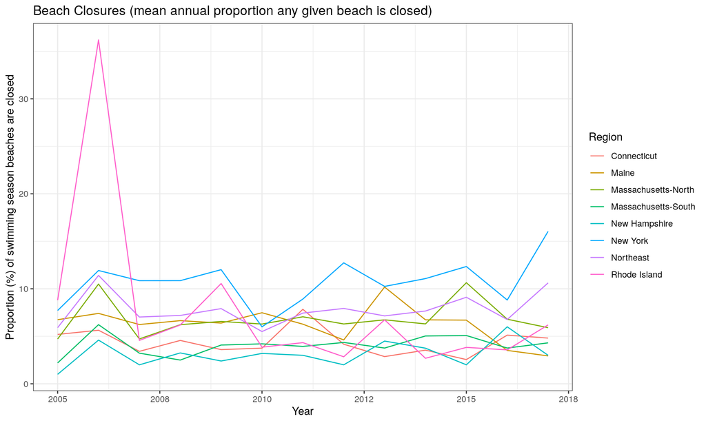

```r
ggplot(perc, aes(x = Year, y = perc_closed*100, color = rgn_name)) +
  geom_line() +
  labs(title = "Beach Closures (mean annual proportion any given beach is closed)",
       y = "Proportion (%) of swimming season beaches are closed",
       color = "Region") +
  theme_bw()
```

## Calculate CW goal layer

The Clean Waters goal will use this data to measure how clean the water is. For this layer we want the final values to be the inverse of closures, so the amount of time each year that the region has beaches open due to clean water from pathogens. We need to add in the other offshore regions and assign NA for the toolbox layer.

```r
other_rgns <- data.frame(year = rep(2005:2017, each = 4),
                         rgn_name = c("Offshore", "Georges Bank", "Gulf of Maine", "Mid-Atlantic Bight"),
                         rgn_id   = c(1,2,3,4),
                         perc_open = NA)

perc %>%
    group_by(rgn_name, rgn_id, Year) %>%
    summarize(perc_open = mean(1-perc_closed)) %>%
    rename(year = Year) %>%
    bind_rows(other_rgns) %>%
    write.csv(file.path(dir_calc, "layers/cw_pathogens.csv")) #save to toolbox
```

## Calculate and save pressure

This data is also used as a pressure in the Index. But since pressure values go from 0 (low pressure) to 1 (highest pressure) we want to use the annual average proportion of beach closures with 100% being the highest (and worst) value possible.

```r
other_rgns <- data.frame(year = rep(2005:2017, each = 4),
                         rgn_name = c("Offshore", "Georges Bank", "Gulf of Maine", "Mid-Atlantic Bight"),
                         rgn_id   = c(1,2,3,4),
                         perc_closed = NA)

perc %>%
    group_by(rgn_name, rgn_id, Year) %>%
    summarize(perc_closed = mean(perc_closed)) %>%
    select(-rgn_name) %>% #remove rgn_name from layer for toolbox
    rename(year = Year) %>%
    write.csv(file.path(dir_calc, "layers/prs_pathogens.csv")) #saved as prs_pathogens b/c this is a pressure
```